# 重賞レース予測レポート【毎時自動更新中】

作成日時: 2025/10/11 10:05:56

☞ [マニュアル(pdf)](https://ryutoro-galois.github.io/keiba-predictor/manual/manual.pdf)

☞ 過去5年の同一レース結果: [2024年](https://ryutoro-galois.github.io/keiba-predictor/report/PredResult_2024y_raceDate_20241005_20241006.html), [2023年](https://ryutoro-galois.github.io/keiba-predictor/report/PredResult_2023y_raceDate_20231007_20231009.html), [2022年](https://ryutoro-galois.github.io/keiba-predictor/report/PredResult_2022y_raceDate_20221008_20221010.html), [2021年](https://ryutoro-galois.github.io/keiba-predictor/report/PredResult_2021y_raceDate_20211009_20211010.html), [2020年](https://ryutoro-galois.github.io/keiba-predictor/report/PredResult_2020y_raceDate_20201010_20201011.html)

☞ 過去4週間の別レース結果: [1週前(10/5)](https://ryutoro-galois.github.io/keiba-predictor/report/PredResult_2025y_raceDate_20251005_20251005.html), [2週前(9/27-28)](https://ryutoro-galois.github.io/keiba-predictor/report/PredResult_2025y_raceDate_20250927_20250928.html), [3週前(9/20-21)](https://ryutoro-galois.github.io/keiba-predictor/report/PredResult_2025y_raceDate_20250920_20250921.html), [4週前(9/13-15)](https://ryutoro-galois.github.io/keiba-predictor/report/PredResult_2025y_raceDate_20250913_20250915.html)

☞ netkeiba: [サウジアラビアRC(GⅢ)](https://race.netkeiba.com/race/shutuba.html?race_id=202505040311&rf=race_list), [アイルランドトロフィー(GⅡ)](https://race.netkeiba.com/race/shutuba.html?race_id=202505040411&rf=race_list), [スワンステークス(GⅡ)](https://race.netkeiba.com/race/shutuba.html?race_id=202508030511&rf=race_list)

## 0. 推し馬予測 (AI予測)

### 【サウジアラビアRC(GⅢ) 2025/10/11(土)】

- 本命(◎): 1-3着内確率(勝負強さ)が1位の馬
- 対抗(◯): 1-3着内確率が2-N位(20%程度以上)の中で予測タイムが最も速い馬
- 3番手(▲): 1-3着内確率が2-N位(20%程度以上)のでダークホース確率が最も高い馬
- 穴: ダークホース確率が上位1-M位(40%程度以上)の中で1-3着内確率が最も高い馬

| 推し馬 | 枠番 | 馬番 | 人気 | オッズ | 馬名 | 騎手 | 調教師 | 予測タイム(sec) | 1_順位 | 1-3着内確率(%) | 2_順位 | ﾀﾞｰｸﾎｰｽ確率(%) | 3_順位 |
| --- | --- | --- | --- | --- | --- | --- | --- | --- | --- | --- | --- | --- | --- |
| 本命(◎) | 6 | 6 | 2 | 4.0 | エコロアルバ | 坂井瑠星 | 田村康仁 | 101.6 | 7.5 | 20.6 | 1 | 1.5 | 7 |
| 対抗(◯) | 5 | 5 | 1 | 2.2 | ゾロアストロ | Ｃ．ルメール | 宮田敬介 | 92.7 | 1.0 | 16.8 | 3 | 0.4 | 8 |
| 3番手(▲) | 1 | 1 | 7 | 28.3 | ガリレア | 杉原誠人 | 清水英克 | 101.6 | 4.5 | 8.4 | 6 | 43.0 | 2 |
| 穴 | 2 | 2 | 8 | 43.3 | マーゴットブロー | 荻野極 | 伊坂重信 | 101.6 | 4.5 | 7.9 | 8 | 43.7 | 1 |

### 【アイルランドトロフィー(GⅡ) 2025/10/12(日)】

- 本命(◎): 1-3着内確率(勝負強さ)が1位の馬
- 対抗(◯): 1-3着内確率が2-N位(20%程度以上)の中で予測タイムが最も速い馬
- 3番手(▲): 1-3着内確率が2-N位(20%程度以上)のでダークホース確率が最も高い馬
- 穴: ダークホース確率が上位1-M位(40%程度以上)の中で1-3着内確率が最も高い馬

| 推し馬 | 枠番 | 馬番 | 人気 | オッズ | 馬名 | 騎手 | 調教師 | 予測タイム(sec) | 1_順位 | 1-3着内確率(%) | 2_順位 | ﾀﾞｰｸﾎｰｽ確率(%) | 3_順位 |
| --- | --- | --- | --- | --- | --- | --- | --- | --- | --- | --- | --- | --- | --- |
| 本命(◎) | 1 | 1 | 3 | 5.0 | アドマイヤマツリ | 武豊 | 宮田敬介 | 109.7 | 2 | 54.5 | 1 | 0.6 | 16 |
| 対抗(◯) | 4 | 8 | 1 | 4.2 | ボンドガール | Ｃ．ルメール | 手塚貴久 | 105.9 | 1 | 33.2 | 3 | 0.7 | 15 |
| 3番手(▲) | 8 | 15 | 5 | 9.2 | ラヴァンダ | 岩田望来 | 中村直也 | 113.0 | 8 | 25.9 | 4 | 1.9 | 10 |
| 穴 | 3 | 6 | 15 | 82.7 | セフィロ | 横山和生 | 菊沢隆徳 | 110.0 | 5 | 12.4 | 11 | 46.6 | 2 |

## 1. 予測チャート (タイム/勝負強さ)

### 【サウジアラビアRC(GⅢ)】

2025/10/11(土), 05_東京, 芝左1600m

[interactive chart not shown]

### 【アイルランドトロフィー(GⅡ)】

2025/10/12(日), 05_東京, 芝1800m

[interactive chart not shown]

## 2. オッズモニタリング (毎時)

### 【サウジアラビアRカップ】

[interactive chart not shown]

### 【アイルランドトロフィー】

[interactive chart not shown]

## 3. 出馬表

### 【サウジアラビアRカップ 2025/10/11(土) 】

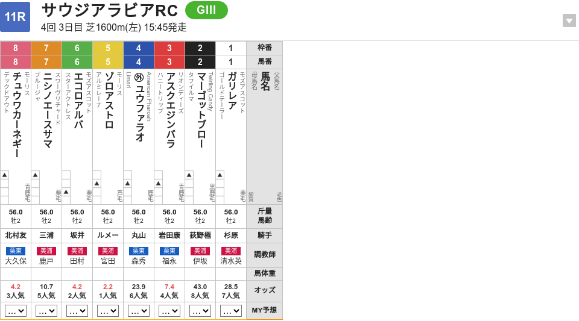

### 【アイルランドトロフィー 2025/10/12(日) 】

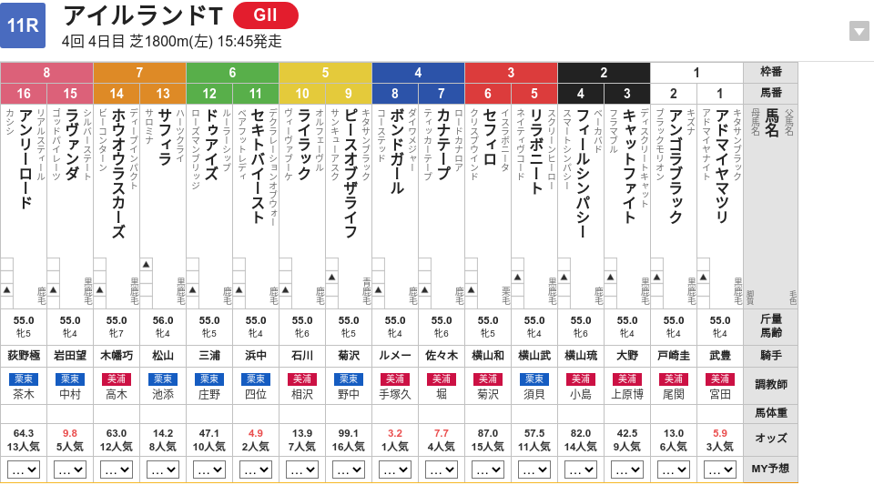

### 【スワンステークス 2025/10/13(月) 】

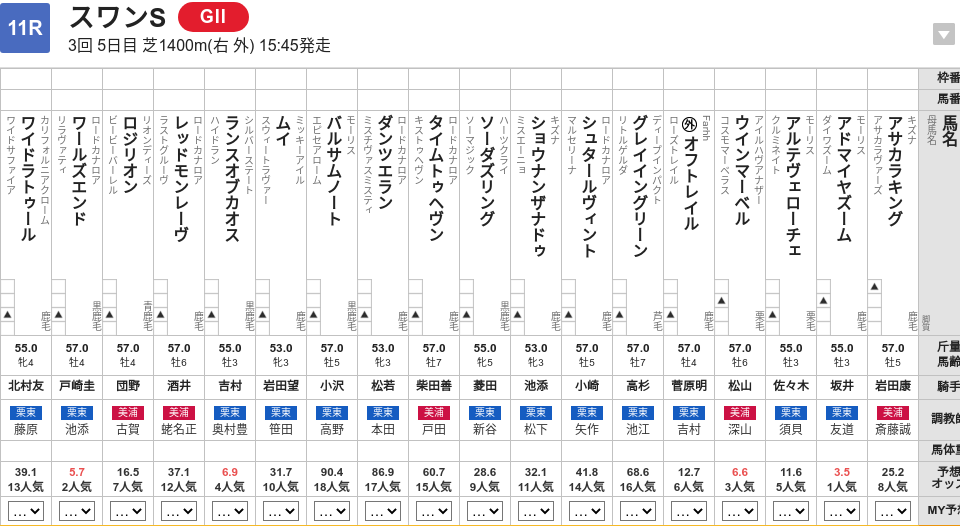

## 4. 単勝予測結果

### 【サウジアラビアRC(GⅢ) 2025/10/11(土)】

| 枠番 | 馬番 | 人気 | オッズ | 馬名 | 騎手 | 調教師 | 予測タイム(sec) | 1_順位 | 1-3着内確率(%) | 2_順位 | ﾀﾞｰｸﾎｰｽ確率(%) | 3_順位 |
| --- | --- | --- | --- | --- | --- | --- | --- | --- | --- | --- | --- | --- |
| 1 | 1 | 7 | 28.3 | ガリレア | 杉原誠人 | 清水英克 | 101.6 | 4.5 | 8.4 | 6 | 43.0 | 2 |
| 2 | 2 | 8 | 43.3 | マーゴットブロー | 荻野極 | 伊坂重信 | 101.6 | 4.5 | 7.9 | 8 | 43.7 | 1 |
| 3 | 3 | 4 | 7.6 | アスクエジンバラ | 岩田康誠 | 福永祐一 | 101.6 | 4.5 | 11.8 | 4 | 1.9 | 5 |
| 4 | 4 | 6 | 25.2 | ユウファラオ | 丸山元気 | 森秀行 | 101.6 | 4.5 | 8.7 | 5 | 38.3 | 3 |
| 5 | 5 | 1 | 2.2 | ゾロアストロ | Ｃ．ルメール | 宮田敬介 | 92.7 | 1.0 | 16.8 | 3 | 0.4 | 8 |
| 6 | 6 | 2 | 4.0 | エコロアルバ | 坂井瑠星 | 田村康仁 | 101.6 | 7.5 | 20.6 | 1 | 1.5 | 7 |
| 7 | 7 | 5 | 11.1 | ニシノエースサマ | 三浦皇成 | 鹿戸雄一 | 100.8 | 2.0 | 8.1 | 7 | 28.9 | 4 |
| 8 | 8 | 3 | 4.2 | チュウワカーネギー | 北村友一 | 大久保龍志 | 101.6 | 7.5 | 19.7 | 2 | 1.7 | 6 |

### 【アイルランドトロフィー(GⅡ) 2025/10/12(日)】

| 枠番 | 馬番 | 人気 | オッズ | 馬名 | 騎手 | 調教師 | 予測タイム(sec) | 1_順位 | 1-3着内確率(%) | 2_順位 | ﾀﾞｰｸﾎｰｽ確率(%) | 3_順位 |
| --- | --- | --- | --- | --- | --- | --- | --- | --- | --- | --- | --- | --- |
| 1 | 1 | 3 | 5.0 | アドマイヤマツリ | 武豊 | 宮田敬介 | 109.7 | 2 | 54.5 | 1 | 0.6 | 16 |
| 1 | 2 | 7 | 12.7 | アンゴラブラック | 戸崎圭太 | 尾関知人 | 110.0 | 4 | 23.7 | 5 | 1.8 | 11 |
| 2 | 3 | 10 | 48.5 | キャットファイト | 大野拓弥 | 上原博之 | 115.5 | 15 | 11.0 | 13 | 25.7 | 6 |
| 2 | 4 | 14 | 82.2 | フィールシンパシー | 横山琉人 | 小島茂之 | 111.7 | 7 | 11.4 | 12 | 60.9 | 1 |
| 3 | 5 | 11 | 60.0 | リラボニート | 横山武史 | 須貝尚介 | 109.7 | 3 | 12.9 | 10 | 35.5 | 3 |
| 3 | 6 | 15 | 82.7 | セフィロ | 横山和生 | 菊沢隆徳 | 110.0 | 5 | 12.4 | 11 | 46.6 | 2 |
| 4 | 7 | 4 | 7.1 | カナテープ | 佐々木大輔 | 堀宣行 | 113.0 | 10 | 16.3 | 7 | 1.1 | 13 |
| 4 | 8 | 1 | 4.2 | ボンドガール | Ｃ．ルメール | 手塚貴久 | 105.9 | 1 | 33.2 | 3 | 0.7 | 15 |
| 5 | 9 | 16 | 108.6 | ピースオブザライフ | 菊沢一樹 | 野中賢二 | 113.0 | 9 | 2.6 | 16 | 10.8 | 8 |
| 5 | 10 | 6 | 12.2 | ライラック | 石川裕紀人 | 相沢郁 | 114.4 | 14 | 15.2 | 8 | 1.4 | 12 |

[output cut: 6 more lines]

## 5. 人気と着順の乖離率推移

### 【サウジアラビアRC_2016y_2019y】

[interactive chart not shown]

### 【サウジアラビアRC_2016y_2019y】

| No | 開催年 | 不整合率(%) | 頭数 | 人気別着順(1-3位) | 人気別着順(全体) |
| --- | --- | --- | --- | --- | --- |
| 4 | 2019 | 8.8 | 9頭 | 1-2-3 | 1\|2\|3\|6\|5\|7\|9\|4\|8 |
| 3 | 2018 | 35.2 | 8頭 | 1-7-4 | 1\|7\|4\|3\|2\|8\|5\|6 |
| 2 | 2017 | 22.5 | 18頭 | 2-1-6 | 2\|1\|6\|3\|5\|4\|9\|7\|12\|11\|13\|16\|14\|15\|10\|17\|8\|18 |
| 1 | 2016 | 53.1 | 9頭 | 3-2-1 | 3\|2\|1\|6\|5\|8\|4\|7\|9 |

## 6. 1-3番人気馬の着順分類予測

### 【サウジアラビアRC】

| 分類 | 凡例 | 発生確率(%) | 当該レース | 当該レースランク | 直近1年間 |
| --- | --- | --- | --- | --- | --- |
| 1: 1番人気のみ (1_pop1) | 1 \| * \| * | 16.8 | 1.68 | 1.68 | 0.00 |
| 4: 1,2番人気のみ (4_pop12) | 1 \| 2 \| * | 16.2 | 1.62 | 1.62 | 0.32 |
| 5: 1,3番人気のみ (5_pop13) | 1 \| 3 \| * | 13.7 | 0.00 | 0.00 | 0.00 |
| 8: 1,2,3番人気すべて着外 (8_darkhorse) | * \| * \| * | 13.7 | 0.00 | 0.00 | 0.00 |
| 7: 1,2,3番人気すべて着内 (7_pop123) | 1 \| 2 \| 3 | 11.4 | 0.14 | 0.14 | 0.23 |
| 2: 2番人気のみ (2_pop2) | 2 \| * \| * | 9.7 | 0.00 | 0.00 | 0.00 |
| 6: 2,3番人気のみ (6_pop23) | 2 \| 3 \| * | 9.5 | 0.00 | 0.00 | 0.00 |
| 3: 3番人気のみ (3_pop3) | 3 \| * \| * | 9.1 | 0.00 | 0.00 | 0.00 |

## 7. 3連複予測結果

### 【サウジアラビアRC(GⅢ) 2025/10/11(土)】

| 分類 | 馬番 | 枠番 | 人気 | 平均予測タイム(sec) | 1-3着内確率(%) | ﾀﾞｰｸﾎｰｽ確率(%) | 馬名 | 騎手 | 調教師 |
| --- | --- | --- | --- | --- | --- | --- | --- | --- | --- |
| 7: 1,2,3番人気すべて着内 (7_pop123) | 5-6-8 | 5-6-8 | 1-2-3 | 98.63 | 0.68 | 0.00 | ゾロアストロ \| エコロアルバ \| チュウワカーネギー | Ｃ．ルメール \| 坂井瑠星 \| 北村友一 | 宮田敬介 \| 田村康仁 \| 大久保龍志 |
| 6: 2,3番人気のみ (6_pop23) | 6-8-3 | 6-8-3 | 2-3-4 | 101.60 | 0.48 | 0.00 | エコロアルバ \| チュウワカーネギー \| アスクエジンバラ | 坂井瑠星 \| 北村友一 \| 岩田康誠 | 田村康仁 \| 大久保龍志 \| 福永祐一 |
| 4: 1,2番人気のみ (4_pop12) | 5-6-3 | 5-6-3 | 1-2-4 | 98.63 | 0.41 | 0.00 | ゾロアストロ \| エコロアルバ \| アスクエジンバラ | Ｃ．ルメール \| 坂井瑠星 \| 岩田康誠 | 宮田敬介 \| 田村康仁 \| 福永祐一 |
| 5: 1,3番人気のみ (5_pop13) | 5-8-3 | 5-8-3 | 1-3-4 | 98.63 | 0.39 | 0.00 | ゾロアストロ \| チュウワカーネギー \| アスクエジンバラ | Ｃ．ルメール \| 北村友一 \| 岩田康誠 | 宮田敬介 \| 大久保龍志 \| 福永祐一 |
| 6: 2,3番人気のみ (6_pop23) | 6-8-4 | 6-8-4 | 2-3-6 | 101.60 | 0.35 | 0.01 | エコロアルバ \| チュウワカーネギー \| ユウファラオ | 坂井瑠星 \| 北村友一 \| 丸山元気 | 田村康仁 \| 大久保龍志 \| 森秀行 |
| 6: 2,3番人気のみ (6_pop23) | 6-8-1 | 6-8-1 | 2-3-7 | 101.60 | 0.34 | 0.01 | エコロアルバ \| チュウワカーネギー \| ガリレア | 坂井瑠星 \| 北村友一 \| 杉原誠人 | 田村康仁 \| 大久保龍志 \| 清水英克 |
| 6: 2,3番人気のみ (6_pop23) | 6-8-7 | 6-8-7 | 2-3-5 | 101.33 | 0.33 | 0.01 | エコロアルバ \| チュウワカーネギー \| ニシノエースサマ | 坂井瑠星 \| 北村友一 \| 三浦皇成 | 田村康仁 \| 大久保龍志 \| 鹿戸雄一 |
| 6: 2,3番人気のみ (6_pop23) | 6-8-2 | 6-8-2 | 2-3-8 | 101.60 | 0.32 | 0.01 | エコロアルバ \| チュウワカーネギー \| マーゴットブロー | 坂井瑠星 \| 北村友一 \| 荻野極 | 田村康仁 \| 大久保龍志 \| 伊坂重信 |
| 4: 1,2番人気のみ (4_pop12) | 5-6-4 | 5-6-4 | 1-2-6 | 98.63 | 0.30 | 0.00 | ゾロアストロ \| エコロアルバ \| ユウファラオ | Ｃ．ルメール \| 坂井瑠星 \| 丸山元気 | 宮田敬介 \| 田村康仁 \| 森秀行 |
| 4: 1,2番人気のみ (4_pop12) | 5-6-1 | 5-6-1 | 1-2-7 | 98.63 | 0.29 | 0.00 | ゾロアストロ \| エコロアルバ \| ガリレア | Ｃ．ルメール \| 坂井瑠星 \| 杉原誠人 | 宮田敬介 \| 田村康仁 \| 清水英克 |

[output cut: 46 more lines]

### 【アイルランドトロフィー(GⅡ) 2025/10/12(日)】

| 分類 | 馬番 | 枠番 | 人気 | 平均予測タイム(sec) | 1-3着内確率(%) | ﾀﾞｰｸﾎｰｽ確率(%) | 馬名 | 騎手 | 調教師 |
| --- | --- | --- | --- | --- | --- | --- | --- | --- | --- |
| 7: 1,2,3番人気すべて着内 (7_pop123) | 8-11-1 | 4-6-1 | 1-2-3 | 109.53 | 6.40 | 0.00 | ボンドガール \| セキトバイースト \| アドマイヤマツリ | Ｃ．ルメール \| 浜中俊 \| 武豊 | 手塚貴久 \| 四位洋文 \| 宮田敬介 |
| 6: 2,3番人気のみ (6_pop23) | 11-1-15 | 6-1-8 | 2-3-5 | 111.90 | 5.00 | 0.00 | セキトバイースト \| アドマイヤマツリ \| ラヴァンダ | 浜中俊 \| 武豊 \| 岩田望来 | 四位洋文 \| 宮田敬介 \| 中村直也 |
| 5: 1,3番人気のみ (5_pop13) | 8-1-15 | 4-1-8 | 1-3-5 | 109.53 | 4.70 | 0.00 | ボンドガール \| アドマイヤマツリ \| ラヴァンダ | Ｃ．ルメール \| 武豊 \| 岩田望来 | 手塚貴久 \| 宮田敬介 \| 中村直也 |
| 6: 2,3番人気のみ (6_pop23) | 11-1-2 | 6-1-1 | 2-3-7 | 110.90 | 4.57 | 0.00 | セキトバイースト \| アドマイヤマツリ \| アンゴラブラック | 浜中俊 \| 武豊 \| 戸崎圭太 | 四位洋文 \| 宮田敬介 \| 尾関知人 |
| 5: 1,3番人気のみ (5_pop13) | 8-1-2 | 4-1-1 | 1-3-7 | 108.53 | 4.29 | 0.00 | ボンドガール \| アドマイヤマツリ \| アンゴラブラック | Ｃ．ルメール \| 武豊 \| 戸崎圭太 | 手塚貴久 \| 宮田敬介 \| 尾関知人 |
| 3: 3番人気のみ (3_pop3) | 1-15-2 | 1-8-1 | 3-5-7 | 110.90 | 3.35 | 0.00 | アドマイヤマツリ \| ラヴァンダ \| アンゴラブラック | 武豊 \| 岩田望来 \| 戸崎圭太 | 宮田敬介 \| 中村直也 \| 尾関知人 |
| 6: 2,3番人気のみ (6_pop23) | 11-1-12 | 6-1-6 | 2-3-9 | 112.87 | 3.24 | 0.00 | セキトバイースト \| アドマイヤマツリ \| ドゥアイズ | 浜中俊 \| 武豊 \| 三浦皇成 | 四位洋文 \| 宮田敬介 \| 庄野靖志 |
| 6: 2,3番人気のみ (6_pop23) | 11-1-7 | 6-1-4 | 2-3-4 | 111.90 | 3.15 | 0.00 | セキトバイースト \| アドマイヤマツリ \| カナテープ | 浜中俊 \| 武豊 \| 佐々木大輔 | 四位洋文 \| 宮田敬介 \| 堀宣行 |
| 4: 1,2番人気のみ (4_pop12) | 8-11-15 | 4-6-8 | 1-2-5 | 110.63 | 3.05 | 0.00 | ボンドガール \| セキトバイースト \| ラヴァンダ | Ｃ．ルメール \| 浜中俊 \| 岩田望来 | 手塚貴久 \| 四位洋文 \| 中村直也 |
| 5: 1,3番人気のみ (5_pop13) | 8-1-12 | 4-1-6 | 1-3-9 | 110.50 | 3.04 | 0.00 | ボンドガール \| アドマイヤマツリ \| ドゥアイズ | Ｃ．ルメール \| 武豊 \| 三浦皇成 | 手塚貴久 \| 宮田敬介 \| 庄野靖志 |

[output cut: 550 more lines]

## 8. 直近の全レース情報

[output not shown]

[output cut: 8 more lines]